# Exploratory Data Analysis of Movies and Shows

Issam Arabi, Emmanuele Sorgente, Eric Maeder

2022-10-23

### Description

This project aims to analyse a data set concerning popular movies using exploratory tools. The said data set initially contains information about 45’466 different shows, organized into the following co-variates. In brackets are the variables we do not treat :

- The show original budget
- The genre categories, i.e. Action, Adventure, …
- The original language the show was created in
- The title
- (a quick overview of the plot)
- A numeric index indicating the show popularity
- The production companies
- (The production country)
- The original release date of the show
- The total revenue
- The show duration in minutes
- A variable named “vote_average” representing the mean note given by users on an integer scale from 1 to 10.
- The total number of said votes

First, we decided to work the data set a bit to adjust the variable types, add interesting variables that are combinations of preexisting ones, and to remove subjectively uninteresting observations. Precisely, we removed from our data movies that have a small (<2000) or unknown budget, are under 10min long, or have under ten votes. Left are 1580 movies.

New variables we deemed interesting to add:

- a binary indicator of whether the show had a low or high production cost (threshold 10’000’000)
- another binary covariate returning ‘true’ if the show was originally produced in english.
- a profit variable, calculated deducing the production cost from the revenue.
- a ternary ‘profitable’ variable, with profit thresholds 0 and 90’000’000.
- a numeric percentprofit covariate corresponding to the profit as a percentage of the initial investment.
- binary variables ‘Action’,‘Adventure’,… indicating whether the show is in said film genres or not.

Moving on to the exploration part, we first investigated the language variable.

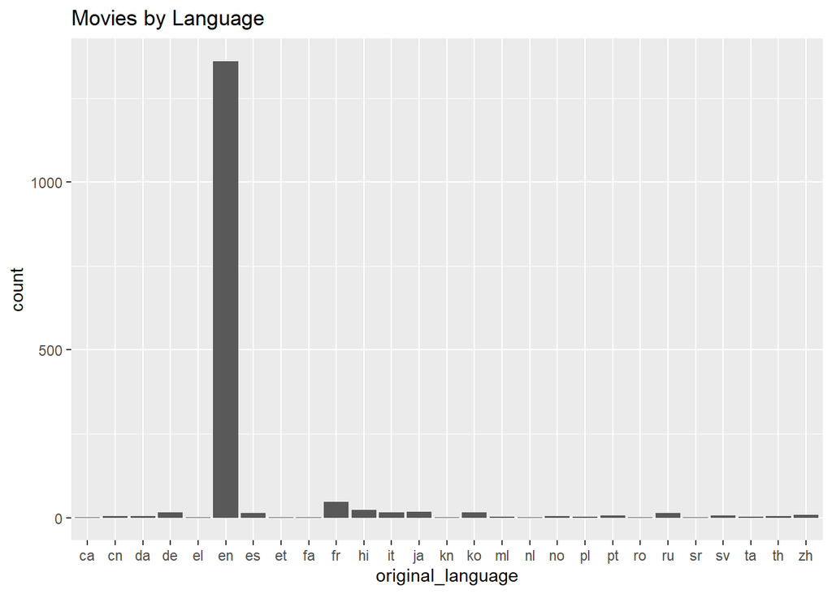

After noticing that most movies were in English, we decided to compare profits of English movies to movies in other languages.

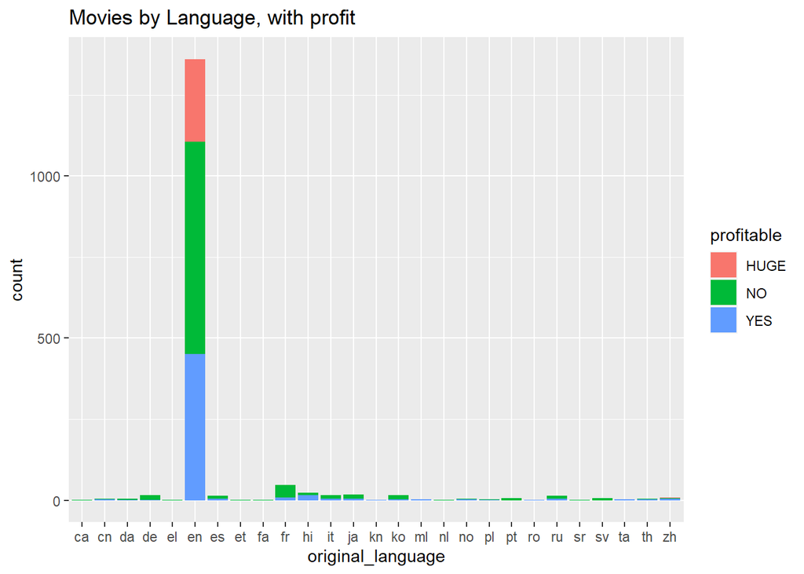

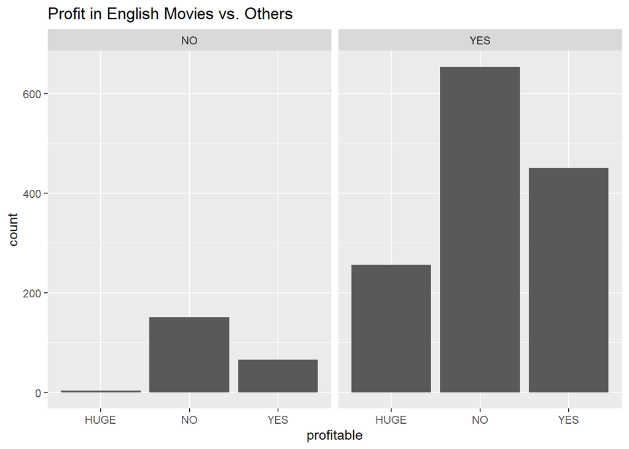

On these two histograms, we can see the proportion of hugely profitable movies is bigger in english, which does not come as a surprise, as english is the main internationally known language around the world. Next, we were interested in exploring the ratings of movies; In particular, we wanted to check wether the ratings of movies had any effect on the profit generated.

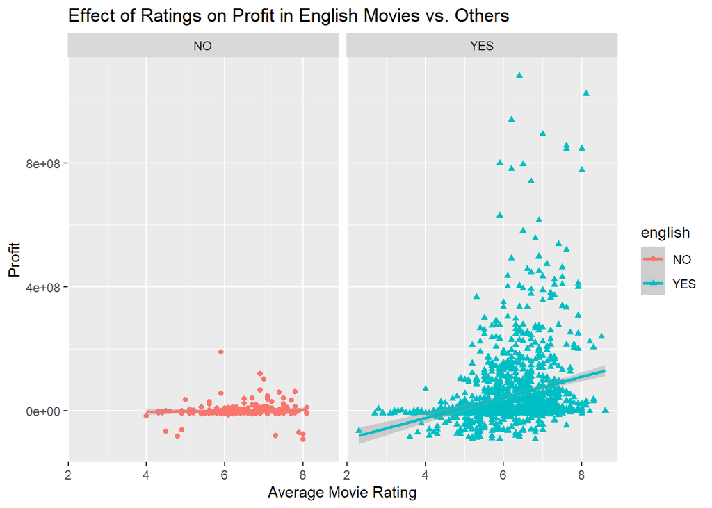

There is a stronger correlation between average vote, representing consumer rating, and profit for english films, although there are few non-english observations, so this induces a higher variance in that matter each time we do such a differentiation.

### Areas of Interest

After exploring the data, the following questions about the data have raised our curiosity:

1. How is the revenue generated by a movie related to its budget?
2. Movies of which languages have the highest rating?
3. Over time, how has the runtime of movies changed (i.e. Are movies getting longer or shorter?)
4. Which companies produce the most popular movies?

### Revenue vs. Budget

To answer the first question, we generated a scatterplot of the revenue against the budget of the films, as well as a scatterplot of the profit against the budget.

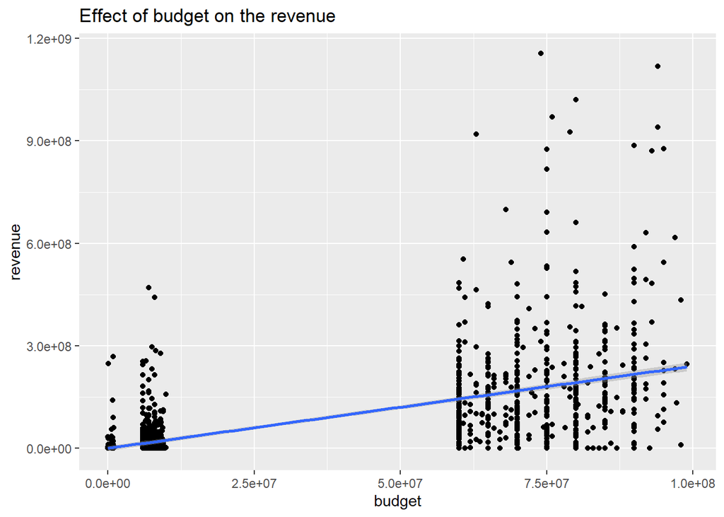

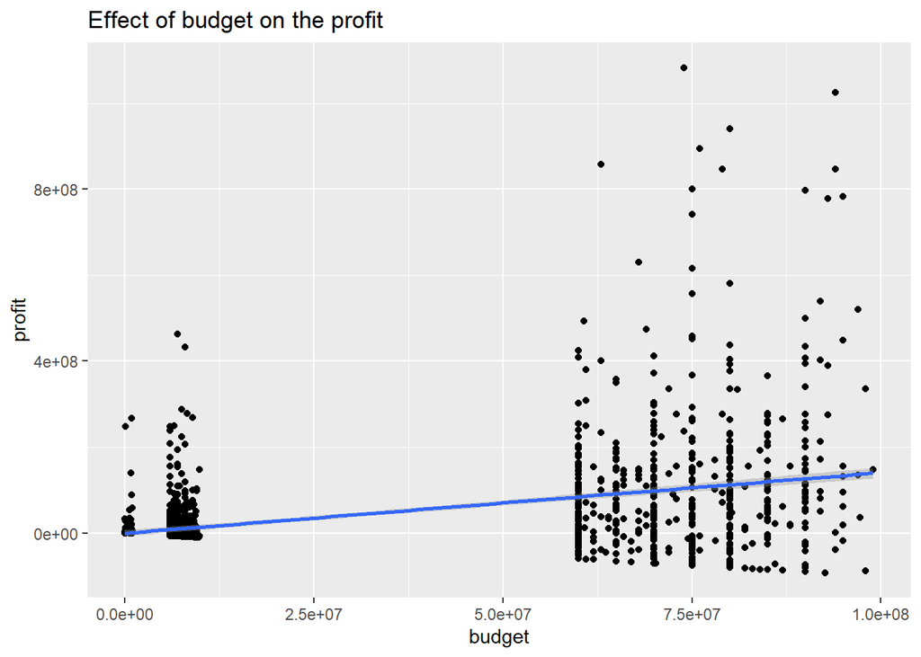

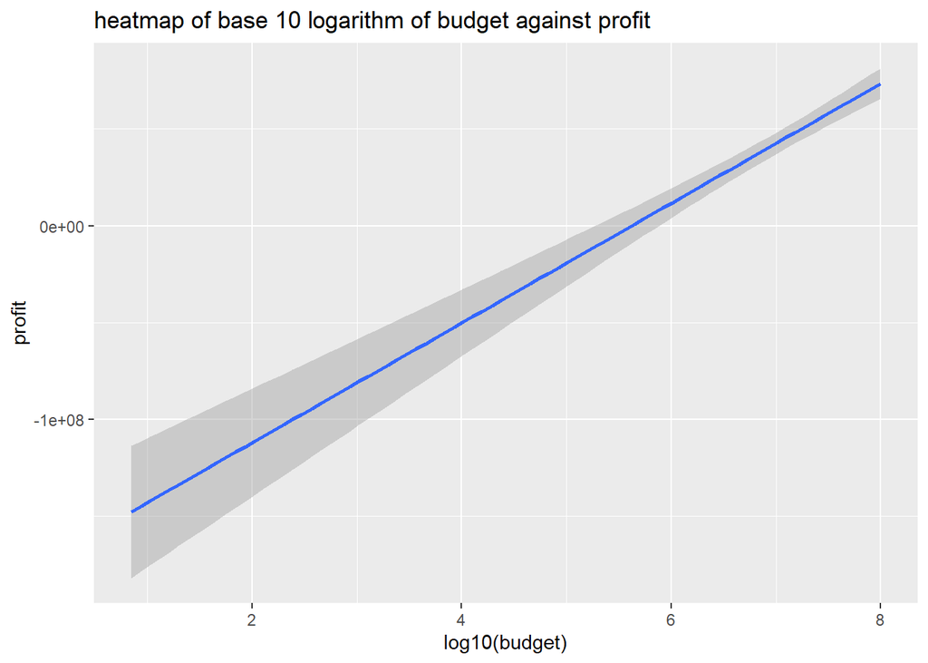

In this dataset, most films have low profit, and this tendency seems to change only for films with high order of budget (10^7 ,10^8).

### Languages with Highest Ratings

Moving on to the second question, we consider a histogram of the rating filled with the original language:

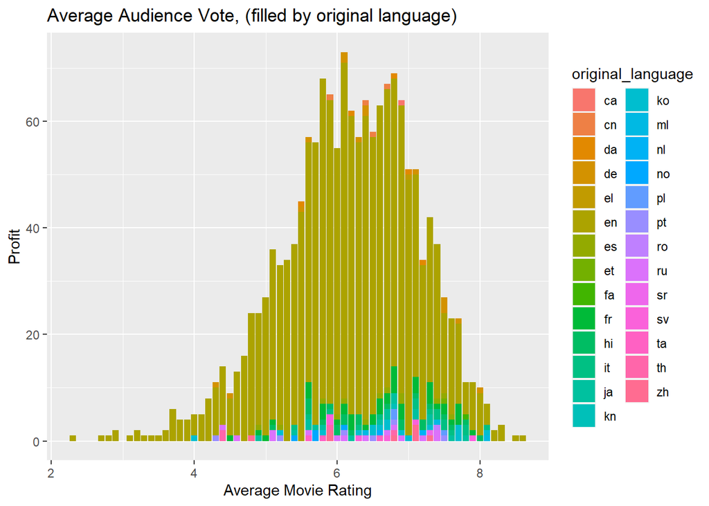

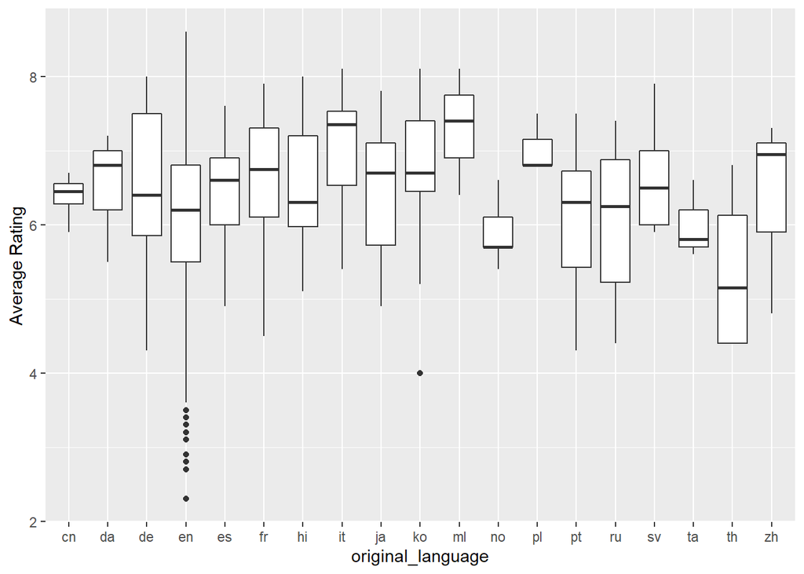

### Movie Length vs. Time

To do so, we first add a ‘year’ variable representing in what year the film came out. In doing so, we lose some precision over the results in hope to gain a better insight of the temporal evolution.

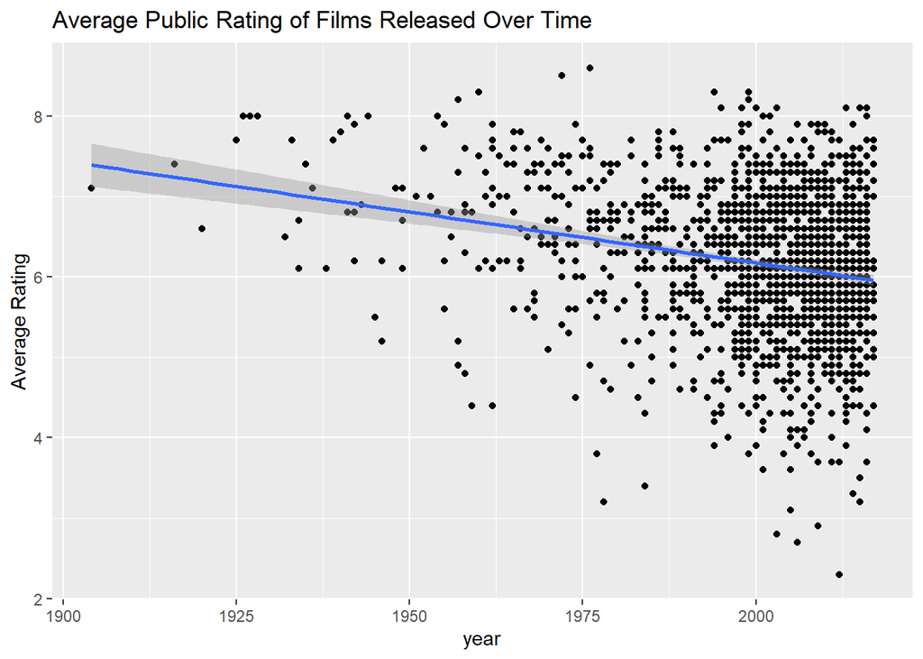

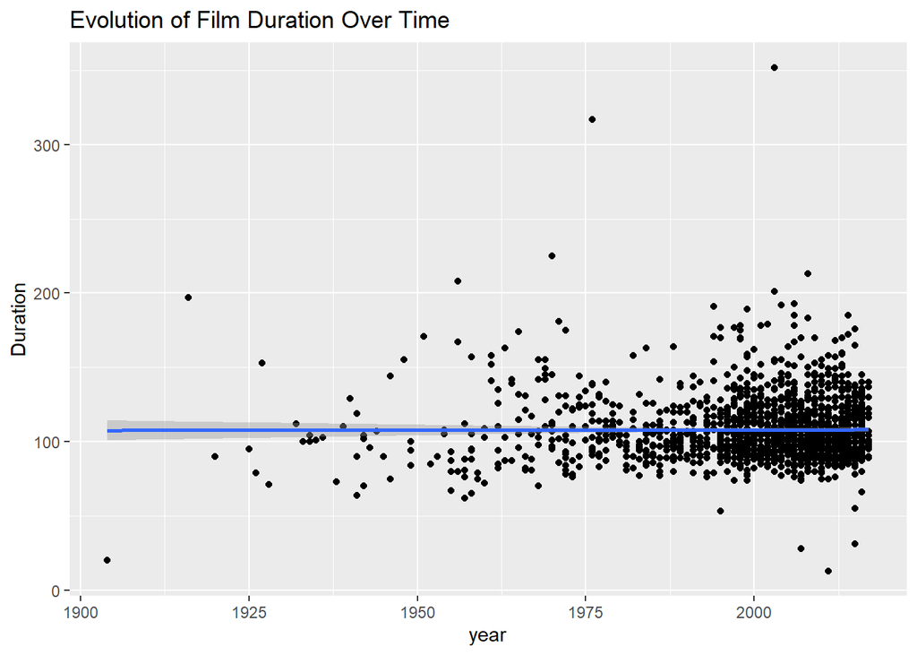

Clearly, there are more and more movies coming out over the decades. The average vote has a decreasing tendency over the years, maybe due to the increasing number of low quality films that comes with the facilitated access to production. Remarkable is also the fact that the average runtime stays around 100 min since around 1920, so it looks as if both covariates were uncorrelated.

### Production Companies with Most Popular Movies

Lastly, we are going to find out which of the following companies produce the most popular movies:

- Paramount Pictures
- DreamWorks
- Walt Disney
- Warner Bros
- Fox Film Corp
- Universal Pictures

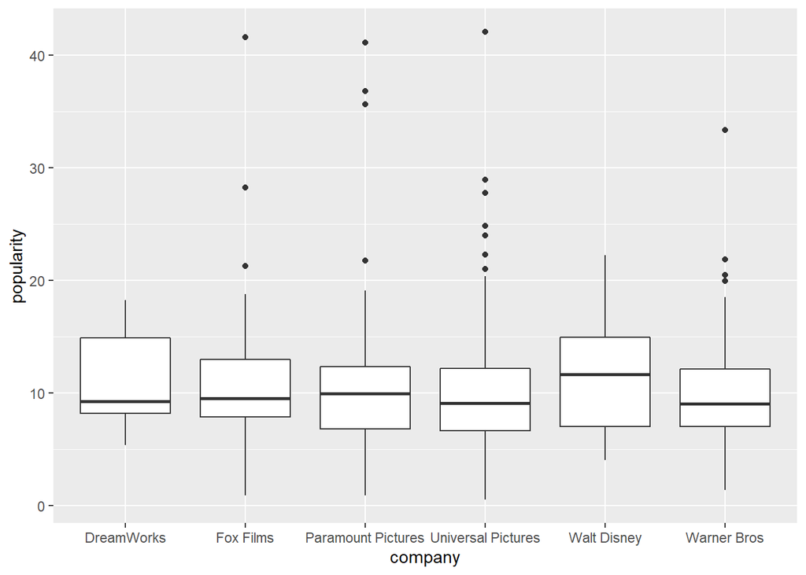

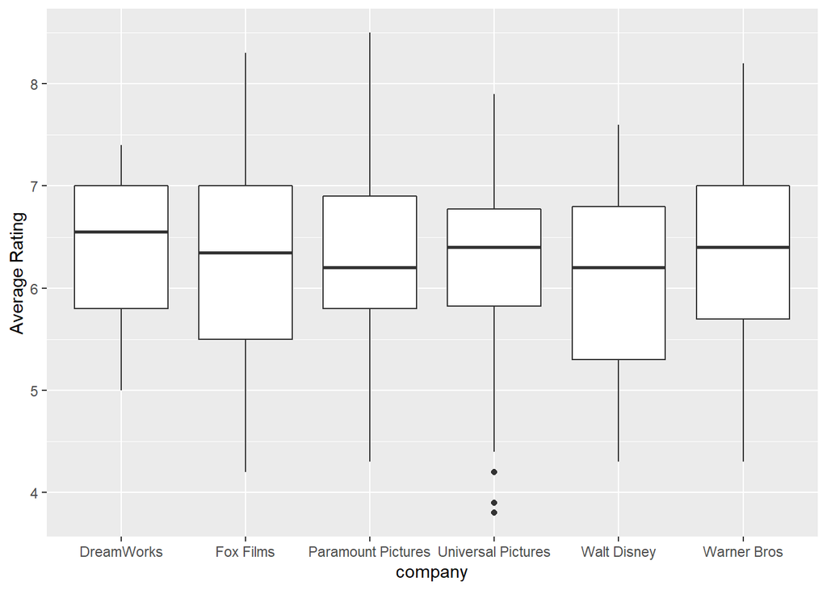

## Conclusion

### Individual Contributions:

- Issam (359405): Took part in researching the data and writing up the description. Also conducted some exploration of data (not shown here). Partially solved the second and fourth questions. Merged the individual contributions of other team members and formatted the HTML file.
- Emanuele: I started the project firstly cleaning the dataset from useless datas. I continued my work manipulating a little dataset, for example adding new coloumns. Then I started exploring the dataset, noticing and plotting some interesting correlations from the dataset.
- Eric (315663): Contributed to producing plots and exploring the data, mainly on the runtime and different production companies. Additionally, he participated to analyse the results and redacting the document.